# Introduction :

Le taux de chômage est un indicateur économique essentiel qui reflète la santé du marché du travail au sein d'un pays. Au Maroc, comme dans de nombreux autres pays, le taux de chômage a des implications significatives sur le bien-être socio-économique de la population. Comprendre et anticiper les variations de ce taux est crucial pour élaborer des politiques publiques efficaces, orientées vers la création d'emplois et la stabilisation de l'économie.

Notre projet vise à aborder cette problématique en développant un modèle de prédiction du taux de chômage au Maroc. Pour ce faire, nous adopterons une approche holistique, couvrant plusieurs phases clés du processus de modélisation. Ces étapes comprennent la collecte de données, le prétraitement, la visualisation des données, l'interprétation, le choix des modèles, la construction des modèles, la validation et enfin, l'utilisation des modèles pour générer des prédictions pertinentes.

# les bibliographies:

```python
import pandas as pd
import numpy as np
import seaborn as sns
import matplotlib.pyplot as plt
from sklearn.model_selection import train_test_split,GridSearchCV
from sklearn.ensemble import RandomForestRegressor, GradientBoostingRegressor
from sklearn.multioutput import MultiOutputRegressor
from sklearn.preprocessing import StandardScaler
from sklearn.metrics import mean_squared_error
from sklearn.metrics import r2_score
from sklearn.tree import DecisionTreeRegressor
```

# Collecte de données:

La première étape de notre projet consiste à rassembler des données pertinentes et fiables liées au marché du travail au Maroc. Cela peut inclure des informations sur l'emploi, le chômage, l'éducation, les secteurs économiques, et d'autres variables pertinentes. La qualité des données est cruciale pour la précision de notre modèle, et nous nous efforcerons d'obtenir des ensembles de données exhaustifs et actualisés.

```python
importation des donnees:
```

```python
data_age_feminin = pd.read_excel(r"C:\Users\dell\OneDrive\Bureau\age F.xlsx")
data_age_masculin = pd.read_excel(r"C:\Users\dell\OneDrive\Bureau\age mascul.xlsx")
data_dip_feminin = pd.read_excel(r"C:\Users\dell\OneDrive\Bureau\DIPMLOME F.xlsx")
data_dip_masculin = pd.read_excel(r"C:\Users\dell\OneDrive\Bureau\diplome M.xlsx")
```

# Prétraitement :

Une fois les données collectées, nous entreprendrons des étapes de prétraitement pour nettoyer et organiser les informations. Cela inclut la gestion des valeurs manquantes, l'élimination des outliers, la normalisation des données, et d'autres techniques visant à rendre les données aptes à être utilisées dans nos modèles de prédiction.

Ajouter la colonne du sex:

```python
data_age_feminin['sex']='F'
data_age_masculin['sex']='M'
data_dip_feminin['sex']='F'
data_dip_masculin['sex']='M'
```

```python
data_dip_feminin.tail()
```

|  | Années | Sans diplôme | Ayant un diplôme: Niveau moyen | Ayant un diplôme: Niveau supérieur | Ensemble | sex |
| --- | --- | --- | --- | --- | --- | --- |
| 19 | 2003 | 3.971339 | 30.482607 | 36.791373 | 12.393370 | F |
| 20 | 2002 | 3.836262 | 29.183204 | 35.270764 | 12.122700 | F |
| 21 | 2001 | 4.063721 | 30.064752 | 35.546434 | 12.200370 | F |
| 22 | 2000 | 4.339589 | 33.001484 | 39.172855 | 12.775613 | F |
| 23 | 1999 | 5.459990 | 34.725906 | 36.162666 | 13.159199 | F |

Regroupement selon l'âge : concaténation des deux sexes dans le même dataframe

```python
data_age = pd.concat([data_age_feminin, data_age_masculin], axis=0)
data_age.head()
```

|  | Années | 15 - 24 | 25 - 34 | 35 - 44 | 45 et plus | Ensemble | sex |
| --- | --- | --- | --- | --- | --- | --- | --- |
| 0 | 2022 | 44.4 | 28.0 | 9.1 | 3.2 | 17.2 | F |
| 1 | 2021 | 41.9 | 26.9 | 9.7 | 4.0 | 16.8 | F |
| 2 | 2020 | 41.2 | 26.2 | 8.9 | 4.0 | 16.2 | F |
| 3 | 2019 | 33.4 | 22.9 | 6.6 | 2.3 | 13.5 | F |
| 4 | 2018 | 34.3 | 23.2 | 7.6 | 2.3 | 14.1 | F |

```python
data_dip = pd.concat([data_dip_feminin, data_dip_masculin], axis=0)
data_dip.head()
```

|  | Années | Sans diplôme | Ayant un diplôme: Niveau moyen | Ayant un diplôme: Niveau supérieur | Ensemble | sex |
| --- | --- | --- | --- | --- | --- | --- |
| 0 | 2022 | 3.8 | 21.5 | 34.8 | 17.2 | F |
| 1 | 2021 | 4.5 | 24.5 | 32.8 | 16.8 | F |
| 2 | 2020 | 4.8 | 24.6 | 31.8 | 16.2 | F |
| 3 | 2019 | 2.9 | 21.3 | 29.5 | 13.5 | F |
| 4 | 2018 | 3.2 | 23.2 | 32.5 | 14.1 | F |

Nombre de lignes/colonnes:

```python
data_age.shape
```

```
(48, 7)
```

```python
data_dip.shape
```

```
(48, 6)
```

```python
data_age.head()
```

|  | Années | 15 - 24 | 25 - 34 | 35 - 44 | 45 et plus | Ensemble | sex |
| --- | --- | --- | --- | --- | --- | --- | --- |
| 0 | 2022 | 44.4 | 28.0 | 9.1 | 3.2 | 17.2 | F |
| 1 | 2021 | 41.9 | 26.9 | 9.7 | 4.0 | 16.8 | F |
| 2 | 2020 | 41.2 | 26.2 | 8.9 | 4.0 | 16.2 | F |
| 3 | 2019 | 33.4 | 22.9 | 6.6 | 2.3 | 13.5 | F |
| 4 | 2018 | 34.3 | 23.2 | 7.6 | 2.3 | 14.1 | F |

```python
data_dip.head()
```

|  | Années | Sans diplôme | Ayant un diplôme: Niveau moyen | Ayant un diplôme: Niveau supérieur | Ensemble | sex |
| --- | --- | --- | --- | --- | --- | --- |
| 0 | 2022 | 3.8 | 21.5 | 34.8 | 17.2 | F |
| 1 | 2021 | 4.5 | 24.5 | 32.8 | 16.8 | F |
| 2 | 2020 | 4.8 | 24.6 | 31.8 | 16.2 | F |
| 3 | 2019 | 2.9 | 21.3 | 29.5 | 13.5 | F |
| 4 | 2018 | 3.2 | 23.2 | 32.5 | 14.1 | F |

Renommer les colonnes:

```python
data_age.columns=['Annes','15-24','25-34','35-44','plus que 45','Ensemble','sex']
```

```python
data_dip.columns=['Annes','sans d','d moyenne','d superieur','Ensemble','sex']
```

Suppression de colonnes ensembles:

```python
data_dip = data_dip.drop(columns = ['Ensemble'])
```

```python
data_age = data_age.drop(columns = ['Ensemble'])
```

Concaténation des deux ensembles de données:

```python
data_final = pd.concat([data_dip, data_age.drop(['Annes', 'sex'], axis=1)], axis = 1)
data_final.head()
```

|  | Annes | sans d | d moyenne | d superieur | sex | 15-24 | 25-34 | 35-44 | plus que 45 |
| --- | --- | --- | --- | --- | --- | --- | --- | --- | --- |
| 0 | 2022 | 3.8 | 21.5 | 34.8 | F | 44.4 | 28.0 | 9.1 | 3.2 |
| 1 | 2021 | 4.5 | 24.5 | 32.8 | F | 41.9 | 26.9 | 9.7 | 4.0 |
| 2 | 2020 | 4.8 | 24.6 | 31.8 | F | 41.2 | 26.2 | 8.9 | 4.0 |
| 3 | 2019 | 2.9 | 21.3 | 29.5 | F | 33.4 | 22.9 | 6.6 | 2.3 |
| 4 | 2018 | 3.2 | 23.2 | 32.5 | F | 34.3 | 23.2 | 7.6 | 2.3 |

Triage du dataset:

```python
data_final = data_final.sort_values(by=['Annes', 'sex'], ascending=[False, False], inplace = False)
```

```python
data_final.shape
```

```
(48, 9)
```

Les valeurs manquantes:

```python
data_final.isnull().sum()
```

```
Annes          0
sans d         0
d moyenne      0
d superieur    0
sex            0
15-24          0
25-34          0
35-44          0
plus que 45    0
dtype: int64
```

Le type de données :

```python
data_final.dtypes
```

```
Annes            int64
sans d         float64
d moyenne      float64
d superieur    float64
sex             object
15-24          float64
25-34          float64
35-44          float64
plus que 45    float64
dtype: object
```

Une statistique rapide sur nos données :

```python
data_final.describe()
```

|  | Annes | sans d | d moyenne | d superieur | 15-24 | 25-34 | 35-44 | plus que 45 |
| --- | --- | --- | --- | --- | --- | --- | --- | --- |
| count | 48.000000 | 48.000000 | 48.000000 | 48.000000 | 48.000000 | 48.000000 | 48.000000 | 48.000000 |
| mean | 2010.500000 | 4.414225 | 20.729897 | 24.918585 | 21.466854 | 17.083513 | 6.267704 | 2.265942 |
| std | 6.995439 | 1.446039 | 5.944504 | 7.418594 | 7.383010 | 4.272988 | 1.267009 | 0.814612 |
| min | 1999.000000 | 2.647612 | 10.800000 | 13.964118 | 14.121230 | 11.466960 | 3.600000 | 0.482458 |
| 25% | 2004.750000 | 3.185581 | 14.750457 | 17.875000 | 16.767681 | 13.142145 | 5.627507 | 1.591111 |
| 50% | 2010.500000 | 4.219795 | 21.045649 | 24.580020 | 18.800561 | 16.194735 | 6.332842 | 2.183733 |
| 75% | 2016.250000 | 5.447532 | 24.525000 | 30.300000 | 22.125000 | 19.935794 | 6.794961 | 2.683076 |
| max | 2022.000000 | 9.131952 | 34.725906 | 39.172855 | 44.400000 | 28.000000 | 9.700000 | 4.000000 |

Changer les valeurs du sexe par des valeurs numériques:

```python
data_final['sex'] = data_final['sex'].replace({'M': 1, 'F': -1})
```

```python
data_final.head()
```

|  | Annes | sans d | d moyenne | d superieur | sex | 15-24 | 25-34 | 35-44 | plus que 45 |
| --- | --- | --- | --- | --- | --- | --- | --- | --- | --- |
| 0 | 2022 | 4.4 | 13.0 | 20.8 | 1 | 28.7 | 16.4 | 5.6 | 3.3 |
| 0 | 2022 | 3.8 | 21.5 | 34.8 | -1 | 44.4 | 28.0 | 9.1 | 3.2 |
| 1 | 2021 | 4.6 | 14.5 | 21.9 | 1 | 28.4 | 17.2 | 6.2 | 3.7 |
| 1 | 2021 | 4.5 | 24.5 | 32.8 | -1 | 41.9 | 26.9 | 9.7 | 4.0 |
| 2 | 2020 | 5.8 | 14.0 | 19.6 | 1 | 28.0 | 16.2 | 6.3 | 3.9 |

# Visualisation des données :

La visualisation des données joue un rôle crucial dans la compréhension des tendances et des relations entre différentes variables. Nous utiliserons des outils graphiques pour représenter les données de manière claire et intuitive, facilitant ainsi l'interprétation des modèles qui seront développés par la suite.

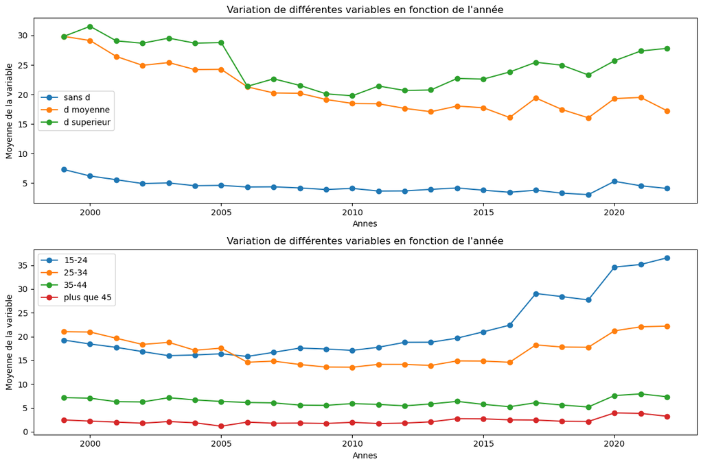

```python
target_diplome= ['sans d', 'd moyenne', 'd superieur']
target_age= ['15-24','25-34','35-44','plus que 45']
plt.figure(figsize=(12, 8))
plt.subplot(2, 1, 1)
for i in target_diplome:
        # Group by 'Annes' and calculate mean
        moyenne_par_annees = data_final.groupby('Annes')[i].mean()

        # Plot each line in the same plot
        plt.plot(moyenne_par_annees.index, moyenne_par_annees.values, marker='o', linestyle='-', label=i)

# Add labels and title
plt.xlabel('Annes')
plt.ylabel('Moyenne de la variable')
plt.title("Variation de différentes variables en fonction de l'année")
plt.legend()
plt.subplot(2, 1, 2)
for i in target_age:
        # Group by 'Annes' and calculate mean
        moyenne_par_annees = data_final.groupby('Annes')[i].mean()

        # Plot each line in the same plot
        plt.plot(moyenne_par_annees.index, moyenne_par_annees.values, marker='o', linestyle='-', label=i)
plt.xlabel('Annes')
plt.ylabel('Moyenne de la variable')
plt.title("Variation de différentes variables en fonction de l'année")
# Add legend
plt.legend()

plt.tight_layout()
plt.show()
```

# Interprétation des résultats:

Taux de chomage selon le diplomes : Le graphe nous montre que le taux de chômage est plus élevé chez les personnes diplômées que chez les personnes non diplômées. En effet, de 1999 à 2005, le taux de chômage chez les personnes diplômées était très élevé, suivi d'une diminution légère . Cependant, à partir de 2020, on observe une reprise de l'augmentation du taux de chômage chez les personnes diplômées. Taux de chomage selon l’age: Le graphique indique que le taux de chômage est plus élevé chez les jeunes que chez les adultes. De 1999 à 2015, le taux de chômage était relativement stable dans toutes les tranches d'âge. Cependant, à partir de 2016, une augmentation progressive s'est manifestée, devenant plus prononcée à partir de 2020. Cette variation du taux de chomage au cours ces années soulève des questions sur les changements socio-économiques ou sur le marché du travail qui pourraient avoir contribué à cette tendance Afin de justifier ces variations, il serait nécessaire d'explorer d'autres facteurs susceptibles d'avoir influencé ces évolutions .Il y a plusieurs facteurs à considérer, mais nous nous avons focalisé sur ceux qui ont une influence majeure et directe sur le taux de chômage, à savoir les épidémies et les investissements de l'État.

```python
new_features = pd.read_excel(r"C:\Users\dell\OneDrive\Bureau\new_features.xlsx")
```

```python
new_features.head()
```

|  | Annes | effet sanitaire | investissement |
| --- | --- | --- | --- |
| 0 | 2022 | 0.5 | 1.663588 |
| 1 | 2022 | 0.5 | 1.663588 |
| 2 | 2021 | 3.0 | 1.596519 |
| 3 | 2021 | 3.0 | 1.596519 |
| 4 | 2020 | 7.0 | 1.169073 |

Étant donné que les indices sont différents, l'objectif est de créer les mêmes indices pour les deux dataframes:

```python
data_final = data_final.reset_index(drop=True)
```

```python
data_final = pd.concat([data_final, new_features.drop(['Annes'], axis=1)], axis = 1)
```

```python
data_final.head()
```

|  | Annes | sans d | d moyenne | d superieur | sex | 15-24 | 25-34 | 35-44 | plus que 45 | effet sanitaire | investissement |
| --- | --- | --- | --- | --- | --- | --- | --- | --- | --- | --- | --- |
| 0 | 2022 | 4.4 | 13.0 | 20.8 | 1 | 28.7 | 16.4 | 5.6 | 3.3 | 0.5 | 1.663588 |
| 1 | 2022 | 3.8 | 21.5 | 34.8 | -1 | 44.4 | 28.0 | 9.1 | 3.2 | 0.5 | 1.663588 |
| 2 | 2021 | 4.6 | 14.5 | 21.9 | 1 | 28.4 | 17.2 | 6.2 | 3.7 | 3.0 | 1.596519 |
| 3 | 2021 | 4.5 | 24.5 | 32.8 | -1 | 41.9 | 26.9 | 9.7 | 4.0 | 3.0 | 1.596519 |
| 4 | 2020 | 5.8 | 14.0 | 19.6 | 1 | 28.0 | 16.2 | 6.3 | 3.9 | 7.0 | 1.169073 |

Corrélation entre les colonnes de notre jeu de données:

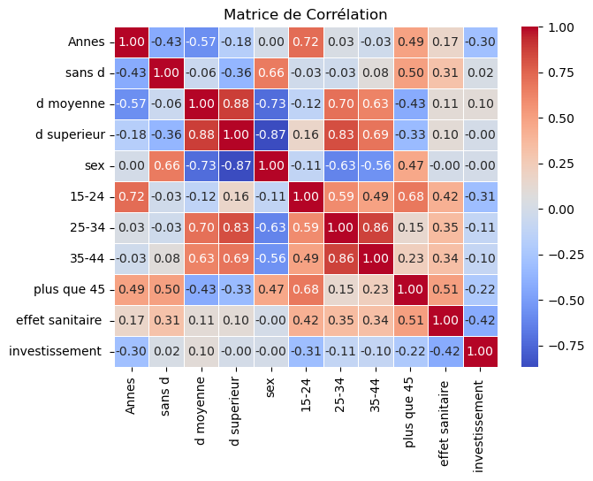

```python
correlation_matrix = data_final.corr()
plt.figure(figsize=(7, 5))
sns.heatmap(correlation_matrix, annot=True, cmap='coolwarm', fmt='.2f', linewidths=.5)
plt.title('Matrice de Corrélation')
plt.show()
```

# Interprétation des résultats :

```python
data_final.head()
```

|  | Annes | sans d | d moyenne | d superieur | sex | 15-24 | 25-34 | 35-44 | plus que 45 | effet sanitaire | investissement |
| --- | --- | --- | --- | --- | --- | --- | --- | --- | --- | --- | --- |
| 0 | 2022 | 4.4 | 13.0 | 20.8 | 1 | 28.7 | 16.4 | 5.6 | 3.3 | 0.5 | 1.663588 |
| 1 | 2022 | 3.8 | 21.5 | 34.8 | -1 | 44.4 | 28.0 | 9.1 | 3.2 | 0.5 | 1.663588 |
| 2 | 2021 | 4.6 | 14.5 | 21.9 | 1 | 28.4 | 17.2 | 6.2 | 3.7 | 3.0 | 1.596519 |
| 3 | 2021 | 4.5 | 24.5 | 32.8 | -1 | 41.9 | 26.9 | 9.7 | 4.0 | 3.0 | 1.596519 |
| 4 | 2020 | 5.8 | 14.0 | 19.6 | 1 | 28.0 | 16.2 | 6.3 | 3.9 | 7.0 | 1.169073 |

Variation de la colonne cible en fonction des années.

```python
data_final.columns=['Annes','sans d','d moyenne','d superieur', 'sex', '15-24','25-34','35-44','plus que 45','effet sanitaire', 'investissement']
```

```python
data_final.head()
```

|  | Annes | sans d | d moyenne | d superieur | sex | 15-24 | 25-34 | 35-44 | plus que 45 | effet sanitaire | investissement |
| --- | --- | --- | --- | --- | --- | --- | --- | --- | --- | --- | --- |
| 0 | 2022 | 4.4 | 13.0 | 20.8 | 1 | 28.7 | 16.4 | 5.6 | 3.3 | 0.5 | 1.663588 |
| 1 | 2022 | 3.8 | 21.5 | 34.8 | -1 | 44.4 | 28.0 | 9.1 | 3.2 | 0.5 | 1.663588 |
| 2 | 2021 | 4.6 | 14.5 | 21.9 | 1 | 28.4 | 17.2 | 6.2 | 3.7 | 3.0 | 1.596519 |
| 3 | 2021 | 4.5 | 24.5 | 32.8 | -1 | 41.9 | 26.9 | 9.7 | 4.0 | 3.0 | 1.596519 |
| 4 | 2020 | 5.8 | 14.0 | 19.6 | 1 | 28.0 | 16.2 | 6.3 | 3.9 | 7.0 | 1.169073 |

Pour appréhender l'essor marqué du chômage en 2020 et 1999, une approche pertinente serait d'élaborer des représentations graphiques illustrant les tendances des facteurs sanitaires et des investissements au fil du temps. En esquissant ces courbes, notre objectif est d'analyser de manière approfondie l'impact des variables liées à la santé et aux investissements, fournissant ainsi un éclairage précis sur les moteurs sous-jacents de la montée du chômage pendant ces deux années cruciales. À travers cette visualisation, nous cherchons à décoder les dynamiques complexes qui ont exercé une influence significative sur le paysage de l'emploi au cours de ces périodes spécifiques.

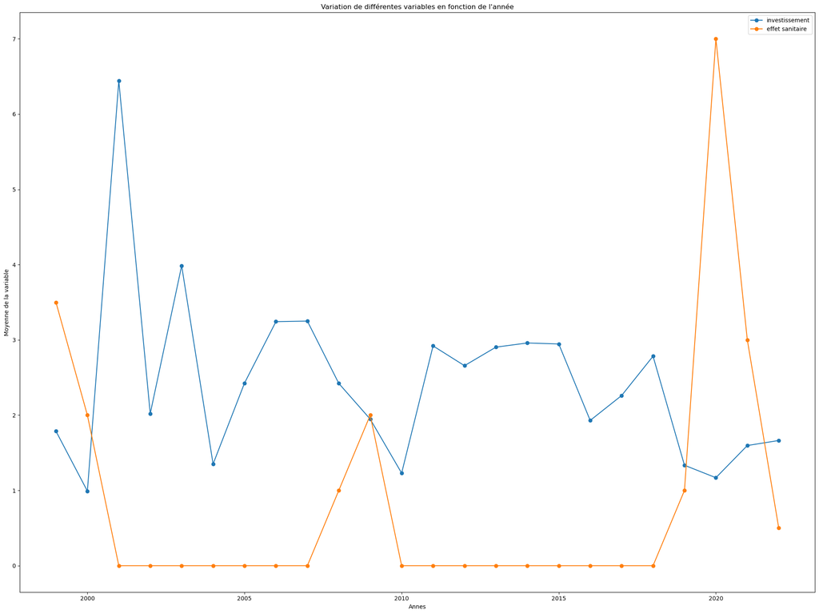

```python
features = ['investissement', 'effet sanitaire']
plt.figure(figsize=(20, 15))
for i in features:
        # Group by 'Annes' and calculate mean
        moyenne_par_annees = data_final.groupby('Annes')[i].mean()

        # Plot each line in the same plot
        plt.plot(moyenne_par_annees.index, moyenne_par_annees.values, marker='o', linestyle='-', label=i)

# Add labels and title
plt.xlabel('Annes')
plt.ylabel('Moyenne de la variable')
plt.title("Variation de différentes variables en fonction de l'année")

# Add legend
plt.legend()

plt.tight_layout()
plt.show()
```

# Interprétation des résultats:

```python
data_final.head()
```

|  | Annes | sans d | d moyenne | d superieur | sex | 15-24 | 25-34 | 35-44 | plus que 45 | effet sanitaire | investissement |
| --- | --- | --- | --- | --- | --- | --- | --- | --- | --- | --- | --- |
| 0 | 2022 | 4.4 | 13.0 | 20.8 | 1 | 28.7 | 16.4 | 5.6 | 3.3 | 0.5 | 1.663588 |
| 1 | 2022 | 3.8 | 21.5 | 34.8 | -1 | 44.4 | 28.0 | 9.1 | 3.2 | 0.5 | 1.663588 |
| 2 | 2021 | 4.6 | 14.5 | 21.9 | 1 | 28.4 | 17.2 | 6.2 | 3.7 | 3.0 | 1.596519 |
| 3 | 2021 | 4.5 | 24.5 | 32.8 | -1 | 41.9 | 26.9 | 9.7 | 4.0 | 3.0 | 1.596519 |
| 4 | 2020 | 5.8 | 14.0 | 19.6 | 1 | 28.0 | 16.2 | 6.3 | 3.9 | 7.0 | 1.169073 |

maintenet on trace la courbe de variation de taux de chomage pour les deux sexe:

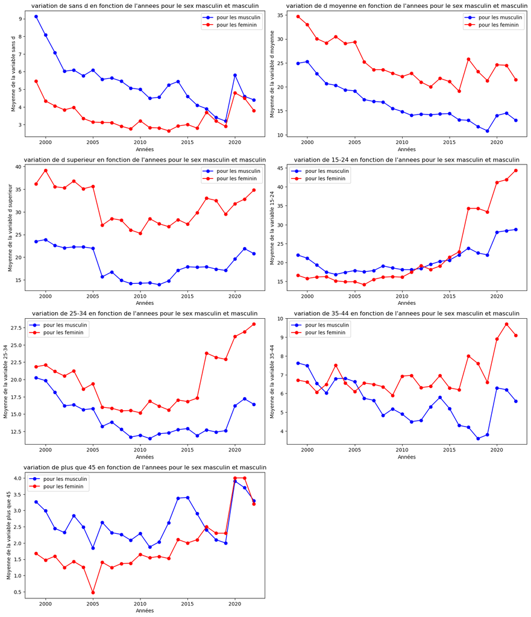

```python
#variation de taux de chomage par sex feminin su fil des annees
plt.figure(figsize = (15, 30))
y=1
for i in target:
        moyeen_par_annees_sexe = data_final.groupby(['sex', 'Annes'])[i].mean()
        par_sexe_M = moyeen_par_annees_sexe[1]
        par_sexe_F = moyeen_par_annees_sexe[-1]

        plt.subplot(7,2,y)
        plt.plot(par_sexe_M.index, par_sexe_M.values, marker='o', linestyle='-', color='b', label='pour les musculin')
        plt.plot(par_sexe_F.index, par_sexe_F.values, marker='o', linestyle='-', color='r', label='pour les feminin')
        plt.legend()
        plt.xlabel('Années')
        plt.ylabel('Moyenne de la variable {}'.format(i))
        plt.title("variation de {} en fonction de l'annees pour le sex masculin et masculin".format(i))
        y+=1
plt.tight_layout()
```

# Interprétation des résultats:

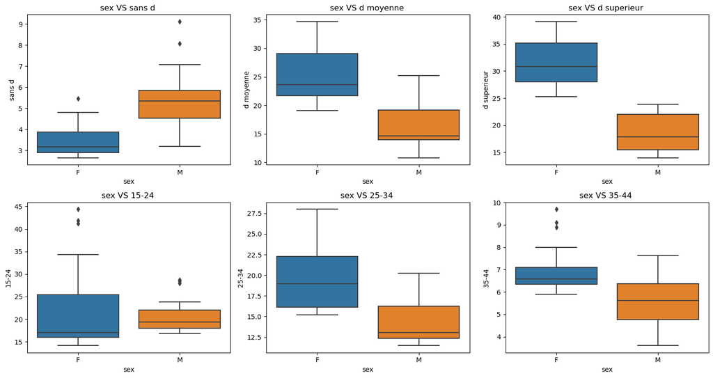

```python
target = ['sans d', 'd moyenne', 'd superieur', '15-24', '25-34', '35-44', 'plus que 45']

fig, ax = plt.subplots(2, 3, figsize=(15, 8))

y = 0
for i in range(2):
    for j in range(3):
        if y < len(target):
            sns.boxplot(x='sex', y=target[y], data=data_final, ax=ax[i, j]).set_title('sex VS {} '.format(target[y]))
            y += 1

plt.tight_layout()
plt.show()
```

Une grille de boxplots est une représentation graphique qui permet de visualiser la distribution des données pour plusieurs variables ou catégories u ainsi les écartilles, le médian et le min et le max valeur . en remarque que le diplôme supérieur est le plus élevé, suivi par ceux ayant une diplôme moyenne.

Standardisation des données:

```python
features = ['Annes', 'sex', 'effet sanitaire', 'investissement']


scaler = StandardScaler()


data_final[features] = scaler.fit_transform(data_final[features])
```

```python
data_final.head()
```

|  | Annes | sans d | d moyenne | d superieur | sex | 15-24 | 25-34 | 35-44 | plus que 45 | effet sanitaire | investissement |
| --- | --- | --- | --- | --- | --- | --- | --- | --- | --- | --- | --- |
| 0 | 1.661325 | 4.4 | 13.0 | 20.8 | 1.0 | 28.7 | 16.4 | 5.6 | 3.3 | -0.204390 | -0.672202 |
| 1 | 1.661325 | 3.8 | 21.5 | 34.8 | -1.0 | 44.4 | 28.0 | 9.1 | 3.2 | -0.204390 | -0.672202 |
| 2 | 1.516862 | 4.6 | 14.5 | 21.9 | 1.0 | 28.4 | 17.2 | 6.2 | 3.7 | 1.328538 | -0.731341 |
| 3 | 1.516862 | 4.5 | 24.5 | 32.8 | -1.0 | 41.9 | 26.9 | 9.7 | 4.0 | 1.328538 | -0.731341 |
| 4 | 1.372399 | 5.8 | 14.0 | 19.6 | 1.0 | 28.0 | 16.2 | 6.3 | 3.9 | 3.781223 | -1.108249 |

Division de la base de données en données d'entraînement (train) et de test (test):

```python
features = ['Annes', 'sex', 'effet sanitaire', 'investissement']
target = ['sans d','d moyenne','d superieur', '15-24','25-34','35-44','plus que 45']

X_train, X_test, y_train, y_test = train_test_split(data_final[features], data_final[target], test_size=0.2, random_state=5)
```

# Prediction du taux de chomage au Maroc

# choix de modele :

on vas utiliser Decision Tree Regressor, Random Forest Regressor et Gradient Boosting Regressor pour predire le taux de chomage au maroc a couse des raison suivantes :

Problème de régression : Les données que vous traitez sont continues ou proches les unes des autres, ce qui indique un problème de régression plutôt qu'un problème de classification. Les modèles de régression sont appropriés pour prédire des valeurs continues.

Nature complexe et non linéaire des données : La complexité et la non-linéarité des données sont des facteurs clés qui motivent le choix de modèles robustes et performants. Les modèles tels que les forêts aléatoires et les boosters sont capables de capturer des relations complexes et de fournir des prédictions précises.

MultiOutputRegressor : La cible comprenant plusieurs colonnes nécessite l'utilisation de la fonction MultiOutputRegressor. Cela permet d'adapter le modèle à plusieurs sorties simultanément, ce qui est approprié dans le cas où vous essayez de prédire plusieurs variables cibles.

# Construction et validaion des modeles:

# Randomforest

```python
param = {
    'estimator__n_estimators': [1000, 3000],
    'estimator__max_depth': [None, 20],
    'estimator__random_state': [42, 567]
}


grid = GridSearchCV(MultiOutputRegressor(estimator=RandomForestRegressor()), param_grid=param, scoring='r2', cv=5)

grid.fit(X_train, y_train)

best_params = grid.best_params_
print("Meilleurs hyperparamètres :", best_params)
best_model = grid.best_estimator_

# Faire des prédictions avec le meilleur modèle
y_train_pred = best_model.predict(X_train)
y_test_pred = best_model.predict(X_test)

# Évaluer la performance
train_r2 = r2_score(y_train, y_train_pred)
test_r2 = r2_score(y_test, y_test_pred)
print('Train R² score:', train_r2)
print('Test R² score:', test_r2)
```

```
Meilleurs hyperparamètres : {'estimator__max_depth': None, 'estimator__n_estimators': 3000, 'estimator__random_state': 42}
Train R² score: 0.9729358598351627
Test R² score: 0.8648293675052423
```

Les résultats fournis pour RandomForestRegressor comprennent les meilleurs hyperparamètres sélectionnés par la recherche sur grille (GridSearchCV) : * estimator__max_depth : None --> La profondeur maximale des arbres est réglée sur "Aucune limite", ce qui signifie que les arbres peuvent se développer jusqu'à ce que chaque feuille contienne un seul point ou qu'un autre critère d'arrêt soit atteint. * estimator__n_estimators : 3000 --> Le nombre d'arbres dans l'ensemble est réglé sur 3000, indiquant la taille de l'ensemble d'arbres. * estimator__random_state : 42 --> Le générateur de nombres aléatoires est fixé à 42 pour assurer la reproductibilité des résultats. R squared score sur le data du training 0.9729 et R squared score sur le data du test est 0.8648 ce qui montrant une excellente performance sur l'ensemble d'entraînement et une bonne capacité de généralisation sur l'ensemble de test

# Decision Trees:

```python
decision_tree =DecisionTreeRegressor(random_state=5)
param_grid = {
    'max_depth': [k for k in range(1,100,10)],
    'min_samples_split': [k for k in range(2,6)],
    'min_samples_leaf': [k for k in range(1,5)]
}


grid_search = GridSearchCV(decision_tree, param_grid, cv=5, scoring='neg_mean_squared_error')
grid_search.fit(X_train, y_train)

print('Les meilleurs paramètres sont:', grid_search.best_params_)

best_model = grid_search.best_estimator_
best_model.fit(X_train,y_train)
x=best_model.score(X_test,y_test)
y=best_model.score(X_train,y_train)
print('test score : ', x, 'train score', y)
```

```
Les meilleurs paramètres sont: {'max_depth': 11, 'min_samples_leaf': 1, 'min_samples_split': 4}
test score :  0.8747152427732499 train score 0.9642488228751727
```

# GradientBoostingRegressor

```python
param = {
    'estimator__n_estimators': [50, 100, 200],
    'estimator__learning_rate': [0.01, 0.1, 0.2],
    'estimator__max_depth': [3, 4, 5],
}

grid = GridSearchCV(MultiOutputRegressor(estimator=GradientBoostingRegressor()), param_grid=param, scoring='r2', cv=5)

grid.fit(X_train, y_train)

best_params = grid.best_params_
print("Meilleurs hyperparamètres :", best_params)
best_model = grid.best_estimator_

# Faire des prédictions avec le meilleur modèle
y_train_pred = best_model.predict(X_train)
y_test_pred = best_model.predict(X_test)

# Évaluer la performance
train_r2 = r2_score(y_train, y_train_pred)
test_r2 = r2_score(y_test, y_test_pred)
print('Train R² score:', train_r2)
print('Test R² score:', test_r2)
```

```
Meilleurs hyperparamètres : {'estimator__learning_rate': 0.01, 'estimator__max_depth': 3, 'estimator__n_estimators': 200}
Train R² score: 0.9479313453909388
Test R² score: 0.8452260052968742
```

voici une cas d'utilisations on va predire le taux de chomage pour 2030 dans les conditions suivant: evenement mondial coup du monde alors les investissment augmenteront jusqu'à 8.66 milliard et le maroc a sortie d'une crise sanitaire depuis 2 ans avant 2030

```python
new_data={'Annes':2030,'sex':[1,-1],'effet sanitaire':2, 'investissement':8.66}
new_data=pd.DataFrame(new_data,columns=['Annes', 'sex', 'effet sanitaire', 'investissement'])
new_data
```

|  | Annes | sex | effet sanitaire | investissement |
| --- | --- | --- | --- | --- |
| 0 | 2030 | 1 | 2 | 8.66 |
| 1 | 2030 | -1 | 2 | 8.66 |

```python
taux_chomage = best_model.predict(new_data)
taux_chomage=pd.DataFrame(taux_chomage,columns=['sans d','d moyenne','d superieur', '15-24','25-34','35-44','plus que 45'])
taux_chomage
```

|  | sans d | d moyenne | d superieur | 15-24 | 25-34 | 35-44 | plus que 45 |
| --- | --- | --- | --- | --- | --- | --- | --- |
| 0 | 5.677926 | 14.216952 | 20.372110 | 25.621112 | 16.345246 | 6.027122 | 3.412469 |
| 1 | 5.071961 | 23.086519 | 32.316922 | 40.754667 | 26.282883 | 8.455695 | 3.278156 |

```python
print("2022\n",data_final.loc[data_final['Annes']==2022,['sans d','d moyenne','d superieur', '15-24','25-34','35-44','plus que 45']])
```

[output not shown]

# principe de GridSearchCv

GridSearchCV est une technique d'optimisation d'hyperparamètres qui permet de rechercher la meilleure combinaison d'hyperparamètres pour un modèle donné. Le principe de GridSearchCV est le suivant :

1. Définition des hyperparamètres à tester : Vous spécifions une grille (ou un ensemble) d'hyperparamètres que vous souhaitez optimiser. Cela peut inclure des paramètres tels que la profondeur maximale d'un arbre de décision, le nombre d'estimateurs dans un modèle d'ensemble, le taux d'apprentissage dans un algorithme de gradient boosting, etc.

2.Choix du modèle : Nous sélectionnons le modèle que Nous souhaitons entraîner et optimiser. Cela peut être n'importe quel modèle de scikit-learn qui expose des paramètres à ajuster.

1. Validation croisée : Nous spécifiez le nombre de plis pour la validation croisée (cv), qui divise votre ensemble de données en plusieurs parties. Le modèle sera entraîné sur certaines parties et évalué sur d'autres. Cela aide à obtenir une évaluation plus robuste des performances du modèle.
2. Création de la grille de recherche : GridSearchCV crée toutes les combinaisons possibles des hyperparamètres que vous avez spécifiés dans la grille. Chaque combinaison est utilisée pour entraîner et évaluer le modèle.
3. Évaluation de la performance : Le modèle est entraîné et évalué pour chaque combinaison d'hyperparamètres à l'aide de la validation croisée. La métrique spécifiée (par exemple, précision, F1-score, erreur quadratique moyenne, etc.) est utilisée pour évaluer la performance.
4. Meilleurs hyperparamètres : Une fois que toutes les combinaisons ont été évaluées, GridSearchCV identifie la combinaison d'hyperparamètres qui a produit les meilleures performances selon la métrique spécifiée.
5. Entraînement du modèle final :
   - Nous pouvons utiliser les meilleurs hyperparamètres pour entraîner le modèle sur l'ensemble complet de données (ou sur un ensemble d'entraînement particulier) afin d'obtenir le modèle final.

   GridSearchCV simplifie le processus d'exploration des hyperparamètres en automatisant la recherche exhaustive, permettant ainsi de trouver la meilleure configuration d'hyperparamètres pour maximiser les performances du modèle. Cependant, cela peut être coûteux en termes de temps de calcul, surtout si la grille de recherche est grande.

# Remarque nous pouvons utiliser aussi la courbe de selectionne ou bien des boucle repititive pour obtenire des matrices carres contiens des scors pour chaque model lié par un certains hyperparamétre et on prendre la moyenne plus elevé

# Gradient boosting regressor

Cet exemple de code utilise la recherche par grille (GridSearchCV) avec la classe MultiOutputRegressor pour optimiser les hyperparamètres d'un modèle de régression par Gradient Boosting (GradientBoostingRegressor) , alors on va expliquer chaque partie de ce code :

1.Définition des hyperparamètres à optimiser :

- n_estimators: Le nombre d'arbres dans le modèle. Plus le nombre est élevé, plus le modèle est complexe.
- learning_rate: Le taux d'apprentissage contrôle la contribution de chaque arbre au modèle. Une valeur plus basse nécessite un nombre plus élevé d'arbres pour atteindre la même complexité.
- max_depth : La profondeur maximale de chaque arbre. Contrôle la complexité de chaque arbre.
1. Création de la grille de recherche (param_grid) :
   - La grille de recherche spécifie toutes les combinaisons possibles des valeurs d'hyperparamètres à tester.
2. Création de l'estimateur (GradientBoostingRegressor) :
   - La classe MultiOutputRegressor est utilisée pour traiter plusieurs sorties simultanément. Dans cet exemple, elle est appliquée à un GradientBoostingRegressor.
3. Création de l'objet GridSearchCV :
   - L'objet GridSearchCV prend l'estimateur, la grille d'hyperparamètres, la métrique de performance (scoring), et le nombre de plis pour la validation croisée (cv).

5.Exécution de la recherche par grille :

- GridSearchCV ajuste le modèle pour chaque combinaison d'hyperparamètres et évalue la performance à l'aide de la validation croisée.
1. Identification des meilleurs hyperparamètres :
   - Une fois la recherche par grille terminée, best*params* contient les valeurs d'hyperparamètres qui ont donné les meilleurs résultats.
2. Entraînement du meilleur modèle :
   - Le meilleur modèle est ensuite ajusté sur l'ensemble d'entraînement complet avec les hyperparamètres optimaux.
3. Prédictions et évaluation de la performance :
   - Le modèle est utilisé pour faire des prédictions sur les ensembles d'entraînement (y_train_pred) et de test (y_test_pred).
   - La performance du modèle est évaluée à l'aide du coefficient de détermination (R²) sur les ensembles d'entraînement et de test.
4. Affichage des résultats :
   - Les résultats finaux, y compris les meilleurs hyperparamètres et les scores R², sont affichés.

Cet exemple illustre comment utiliser la recherche par grille pour ajuster les hyperparamètres d'un modèle de Gradient Boosting avec prise en charge de multiples sorties grâce à MultiOutputRegressor.